# Project - Supervised Classifcation - Loan Modelling

## Background and Context

AllLife Bank is a US bank that has a growing customer base. The majority of these customers are liability customers (depositors) with varying sizes of deposits. The number of customers who are also borrowers (asset customers) is quite small, and the bank is interested in expanding this base rapidly to bring in more loan business and in the process, earn more through the interest on loans. In particular, the management wants to explore ways of converting its liability customers to personal loan customers (while retaining them as depositors).

A campaign that the bank ran last year for liability customers showed a healthy conversion rate of over 9% success. This has encouraged the retail marketing department to devise campaigns with better target marketing to increase the success ratio.

We need to build a model that will help the marketing department to identify the potential customers who have a higher probability of purchasing the loan.

## Objective

To predict whether a liability customer will buy a personal loan or not. Which variables are most significant. Which segment of customers should be targeted more.

## Key Questions

1. What are the key factors influencing whether a liability customer will buy a personal loan or not?
2. Is there a good predictive model so that we can increase the conversion rate of the campaign?
3. What does the performance assessment look like for such a model?

## Data Dictionary

- ID: Customer ID
- Age: Customer’s age in completed years
- Experience: #years of professional experience
- Income: Annual income of the customer (in thousand dollars)
- ZIP Code: Home Address ZIP code.
- Family: the Family size of the customer
- CCAvg: Average spending on credit cards per month (in thousand dollars)
- Education: Education Level. 1: Undergrad; 2: Graduate;3: Advanced/Professional
- Mortgage: Value of house mortgage if any. (in thousand dollars)
- Personal_Loan: Did this customer accept the personal loan offered in the last campaign?
- Securities_Account: Does the customer have securities account with the bank?
- CD_Account: Does the customer have a certificate of deposit (CD) account with the bank?
- Online: Do customers use internet banking facilities?
- CreditCard: Does the customer use a credit card issued by any other Bank (excluding All life Bank)?

## Import necessary libraries and load data

```python
# Libraries to help with reading and manipulating data
import pandas as pd
import numpy as np

# Libraries to help with data visualization
import matplotlib.pyplot as plt
import seaborn as sns
%matplotlib inline

# Removes the limit from the number of displayed columns and rows.
# This is so that we can see the entire dataframe when we print it
pd.set_option('display.max_columns', None)
# pd.set_option('display.max_rows', None)
pd.set_option('display.max_rows', 200)
# We are setting the random seed via np.random.seed so that
# we get the same random results every time
np.random.seed(1)
```

```python
# Load the loan modelling CSV file
data = pd.read_csv('Loan_Modelling.csv')
```

```python
print(f'Number of rows: {data.shape[0]} and number of columns: {data.shape[1]}')
```

```
Number of rows: 5000 and number of columns: 14
```

```python
# Check the first 5 rows of data
data.head()
```

|  | ID | Age | Experience | Income | ZIPCode | Family | CCAvg | Education | Mortgage | Personal_Loan | Securities_Account | CD_Account | Online | CreditCard |
| --- | --- | --- | --- | --- | --- | --- | --- | --- | --- | --- | --- | --- | --- | --- |
| 0 | 1 | 25 | 1 | 49 | 91107 | 4 | 1.6 | 1 | 0 | 0 | 1 | 0 | 0 | 0 |
| 1 | 2 | 45 | 19 | 34 | 90089 | 3 | 1.5 | 1 | 0 | 0 | 1 | 0 | 0 | 0 |
| 2 | 3 | 39 | 15 | 11 | 94720 | 1 | 1.0 | 1 | 0 | 0 | 0 | 0 | 0 | 0 |
| 3 | 4 | 35 | 9 | 100 | 94112 | 1 | 2.7 | 2 | 0 | 0 | 0 | 0 | 0 | 0 |
| 4 | 5 | 35 | 8 | 45 | 91330 | 4 | 1.0 | 2 | 0 | 0 | 0 | 0 | 0 | 1 |

```python
# Check the last 5 rows of data
data.tail()
```

|  | ID | Age | Experience | Income | ZIPCode | Family | CCAvg | Education | Mortgage | Personal_Loan | Securities_Account | CD_Account | Online | CreditCard |
| --- | --- | --- | --- | --- | --- | --- | --- | --- | --- | --- | --- | --- | --- | --- |
| 4995 | 4996 | 29 | 3 | 40 | 92697 | 1 | 1.9 | 3 | 0 | 0 | 0 | 0 | 1 | 0 |
| 4996 | 4997 | 30 | 4 | 15 | 92037 | 4 | 0.4 | 1 | 85 | 0 | 0 | 0 | 1 | 0 |
| 4997 | 4998 | 63 | 39 | 24 | 93023 | 2 | 0.3 | 3 | 0 | 0 | 0 | 0 | 0 | 0 |
| 4998 | 4999 | 65 | 40 | 49 | 90034 | 3 | 0.5 | 2 | 0 | 0 | 0 | 0 | 1 | 0 |
| 4999 | 5000 | 28 | 4 | 83 | 92612 | 3 | 0.8 | 1 | 0 | 0 | 0 | 0 | 1 | 1 |

```python
# checking column names, datatypes and number of non-null values
data.info()
```

```
<class 'pandas.core.frame.DataFrame'>
RangeIndex: 5000 entries, 0 to 4999
Data columns (total 14 columns):
 #   Column              Non-Null Count  Dtype
---  ------              --------------  -----
 0   ID                  5000 non-null   int64
 1   Age                 5000 non-null   int64
 2   Experience          5000 non-null   int64
 3   Income              5000 non-null   int64
 4   ZIPCode             5000 non-null   int64
 5   Family              5000 non-null   int64
 6   CCAvg               5000 non-null   float64
 7   Education           5000 non-null   int64
 8   Mortgage            5000 non-null   int64
 9   Personal_Loan       5000 non-null   int64
 10  Securities_Account  5000 non-null   int64
 11  CD_Account          5000 non-null   int64
 12  Online              5000 non-null   int64
 13  CreditCard          5000 non-null   int64
dtypes: float64(1), int64(13)
memory usage: 547.0 KB
```

```python
# Checking for missing values.
data.isnull().sum()
```

```
ID                    0
Age                   0
Experience            0
Income                0
ZIPCode               0
Family                0
CCAvg                 0
Education             0
Mortgage              0
Personal_Loan         0
Securities_Account    0
CD_Account            0
Online                0
CreditCard            0
dtype: int64
```

```python
# Checking for duplicate rows.
data.duplicated().sum()
```

```
0
```

**Observations:**

- ID column can be dropped as it is a serial number and does not contain any useful information
- There are no null or missing values in the data.
- There are no duplicate records.
- All column types are numeric.

```python
# Not interested in the ID column so we are going to drop the ID column
data.drop(['ID'], axis=1, inplace=True)
```

```python
# Check the Summary of the data
data.describe().T
```

|  | count | mean | std | min | 25% | 50% | 75% | max |
| --- | --- | --- | --- | --- | --- | --- | --- | --- |
| Age | 5000.0 | 45.338400 | 11.463166 | 23.0 | 35.0 | 45.0 | 55.0 | 67.0 |
| Experience | 5000.0 | 20.104600 | 11.467954 | -3.0 | 10.0 | 20.0 | 30.0 | 43.0 |
| Income | 5000.0 | 73.774200 | 46.033729 | 8.0 | 39.0 | 64.0 | 98.0 | 224.0 |
| ZIPCode | 5000.0 | 93169.257000 | 1759.455086 | 90005.0 | 91911.0 | 93437.0 | 94608.0 | 96651.0 |
| Family | 5000.0 | 2.396400 | 1.147663 | 1.0 | 1.0 | 2.0 | 3.0 | 4.0 |
| CCAvg | 5000.0 | 1.937938 | 1.747659 | 0.0 | 0.7 | 1.5 | 2.5 | 10.0 |
| Education | 5000.0 | 1.881000 | 0.839869 | 1.0 | 1.0 | 2.0 | 3.0 | 3.0 |
| Mortgage | 5000.0 | 56.498800 | 101.713802 | 0.0 | 0.0 | 0.0 | 101.0 | 635.0 |
| Personal_Loan | 5000.0 | 0.096000 | 0.294621 | 0.0 | 0.0 | 0.0 | 0.0 | 1.0 |
| Securities_Account | 5000.0 | 0.104400 | 0.305809 | 0.0 | 0.0 | 0.0 | 0.0 | 1.0 |
| CD_Account | 5000.0 | 0.060400 | 0.238250 | 0.0 | 0.0 | 0.0 | 0.0 | 1.0 |
| Online | 5000.0 | 0.596800 | 0.490589 | 0.0 | 0.0 | 1.0 | 1.0 | 1.0 |
| CreditCard | 5000.0 | 0.294000 | 0.455637 | 0.0 | 0.0 | 0.0 | 1.0 | 1.0 |

**Observations:**

- *Age*: Varies from 23 to 67 years with mean and median around 45 years. This data range looks good.
- *Experience*: Ranges from -3 to 43 years. Negative value for professional experience does not make sense. It could be data input errors. We shall inspect the values and take corrective steps.
- *Income*: Minimum is 8K and max is 224K. Mean is around 73K and median 64K. This data range looks good and no correction is required.
- *ZIPCode*: All zip codes are from 90005 to 96651. Hence data appears to be from state of California. We need to figure out a strategy to convert this data to a set of categorical values.
- *Family*: Customer family size with min 1 and maximum 4 and mean/median around 2. This data range looks good.
- *CCAvg*: Average spending on credit cards per month varies from 0 to 10K with mean of 2k and median of 1.5K. This data range also looks good.
- *Education*: Education column is a category column values are 1(Undergraduate), 2(Graduate) or 3(Advanced/Professional).
- *Mortgage*: Value of house mortgage also seems normal and varies from 0 to 635K. Median value of morgage is 0 since most of the customers will not have mortgage.
- *Personal_Loan*: This is our target variable and is of type binary 0 or 1(accepted the personal loan offer).
- *Securities_Account*, *CD_Account*, *Online*, *CreditCard*: All these columns are again binary type categorical variables with 0 and 1 values. Data summary shows no abnormality in the data values.

Other than Age, Experience, Income, CCAvg and Mortgage all other features of categorial type based on the data definitions. Lets check the range of values for these categorical variables to make sure they are categorical and the size of the unique values in them.

```python
cat_cols = ['ZIPCode', 'Family', 'Education', 'Personal_Loan', 'Securities_Account', 'CD_Account', 'Online', 'CreditCard']
for col in cat_cols:
    print('>> Domain of: ', col)
    cat = data[col].value_counts(dropna=False).sort_values(ascending=False)
    print(cat)
    print('-------------------------------\n')
```

```
>> Domain of:  ZIPCode
94720    169
94305    127
95616    116
90095     71
93106     57
        ...
94965      1
94970      1
94598      1
93077      1
94404      1
Name: ZIPCode, Length: 467, dtype: int64
-------------------------------

>> Domain of:  Family
1    1472
2    1296
4    1222
3    1010
Name: Family, dtype: int64
-------------------------------

>> Domain of:  Education
1    2096
3    1501
2    1403
Name: Education, dtype: int64
-------------------------------

>> Domain of:  Personal_Loan
0    4520
1     480
Name: Personal_Loan, dtype: int64
-------------------------------

>> Domain of:  Securities_Account
0    4478
1     522
Name: Securities_Account, dtype: int64
-------------------------------

>> Domain of:  CD_Account
0    4698
1     302
Name: CD_Account, dtype: int64
-------------------------------

>> Domain of:  Online
1    2984
0    2016
Name: Online, dtype: int64
-------------------------------

>> Domain of:  CreditCard
0    3530
1    1470
Name: CreditCard, dtype: int64
-------------------------------
```

**Observations:**

- ZIP codes have 467 unique values. We are going to convert ZIP codes to a more manageable categorical type.
- Other categorical values are as described in the data definition hence we are good with them.

### Fixing negative Experience Values

```python
# Check the rows where we have negative Professional Experience
len(data[data.Experience < 0])
```

```
52
```

```python
# Lets check all the rows, since there are 52
data[data.Experience < 0]
```

|  | Age | Experience | Income | ZIPCode | Family | CCAvg | Education | Mortgage | Personal_Loan | Securities_Account | CD_Account | Online | CreditCard |
| --- | --- | --- | --- | --- | --- | --- | --- | --- | --- | --- | --- | --- | --- |
| 89 | 25 | -1 | 113 | 94303 | 4 | 2.30 | 3 | 0 | 0 | 0 | 0 | 0 | 1 |
| 226 | 24 | -1 | 39 | 94085 | 2 | 1.70 | 2 | 0 | 0 | 0 | 0 | 0 | 0 |
| 315 | 24 | -2 | 51 | 90630 | 3 | 0.30 | 3 | 0 | 0 | 0 | 0 | 1 | 0 |
| 451 | 28 | -2 | 48 | 94132 | 2 | 1.75 | 3 | 89 | 0 | 0 | 0 | 1 | 0 |
| 524 | 24 | -1 | 75 | 93014 | 4 | 0.20 | 1 | 0 | 0 | 0 | 0 | 1 | 0 |
| 536 | 25 | -1 | 43 | 92173 | 3 | 2.40 | 2 | 176 | 0 | 0 | 0 | 1 | 0 |
| 540 | 25 | -1 | 109 | 94010 | 4 | 2.30 | 3 | 314 | 0 | 0 | 0 | 1 | 0 |
| 576 | 25 | -1 | 48 | 92870 | 3 | 0.30 | 3 | 0 | 0 | 0 | 0 | 0 | 1 |
| 583 | 24 | -1 | 38 | 95045 | 2 | 1.70 | 2 | 0 | 0 | 0 | 0 | 1 | 0 |
| 597 | 24 | -2 | 125 | 92835 | 2 | 7.20 | 1 | 0 | 0 | 1 | 0 | 0 | 1 |
| 649 | 25 | -1 | 82 | 92677 | 4 | 2.10 | 3 | 0 | 0 | 0 | 0 | 1 | 0 |
| 670 | 23 | -1 | 61 | 92374 | 4 | 2.60 | 1 | 239 | 0 | 0 | 0 | 1 | 0 |
| 686 | 24 | -1 | 38 | 92612 | 4 | 0.60 | 2 | 0 | 0 | 0 | 0 | 1 | 0 |
| 793 | 24 | -2 | 150 | 94720 | 2 | 2.00 | 1 | 0 | 0 | 0 | 0 | 1 | 0 |
| 889 | 24 | -2 | 82 | 91103 | 2 | 1.60 | 3 | 0 | 0 | 0 | 0 | 1 | 1 |
| 909 | 23 | -1 | 149 | 91709 | 1 | 6.33 | 1 | 305 | 0 | 0 | 0 | 0 | 1 |
| 1173 | 24 | -1 | 35 | 94305 | 2 | 1.70 | 2 | 0 | 0 | 0 | 0 | 0 | 0 |
| 1428 | 25 | -1 | 21 | 94583 | 4 | 0.40 | 1 | 90 | 0 | 0 | 0 | 1 | 0 |
| 1522 | 25 | -1 | 101 | 94720 | 4 | 2.30 | 3 | 256 | 0 | 0 | 0 | 0 | 1 |
| 1905 | 25 | -1 | 112 | 92507 | 2 | 2.00 | 1 | 241 | 0 | 0 | 0 | 1 | 0 |
| 2102 | 25 | -1 | 81 | 92647 | 2 | 1.60 | 3 | 0 | 0 | 0 | 0 | 1 | 1 |
| 2430 | 23 | -1 | 73 | 92120 | 4 | 2.60 | 1 | 0 | 0 | 0 | 0 | 1 | 0 |
| 2466 | 24 | -2 | 80 | 94105 | 2 | 1.60 | 3 | 0 | 0 | 0 | 0 | 1 | 0 |
| 2545 | 25 | -1 | 39 | 94720 | 3 | 2.40 | 2 | 0 | 0 | 0 | 0 | 1 | 0 |
| 2618 | 23 | -3 | 55 | 92704 | 3 | 2.40 | 2 | 145 | 0 | 0 | 0 | 1 | 0 |
| 2717 | 23 | -2 | 45 | 95422 | 4 | 0.60 | 2 | 0 | 0 | 0 | 0 | 1 | 1 |
| 2848 | 24 | -1 | 78 | 94720 | 2 | 1.80 | 2 | 0 | 0 | 0 | 0 | 0 | 0 |
| 2876 | 24 | -2 | 80 | 91107 | 2 | 1.60 | 3 | 238 | 0 | 0 | 0 | 0 | 0 |
| 2962 | 23 | -2 | 81 | 91711 | 2 | 1.80 | 2 | 0 | 0 | 0 | 0 | 0 | 0 |
| 2980 | 25 | -1 | 53 | 94305 | 3 | 2.40 | 2 | 0 | 0 | 0 | 0 | 0 | 0 |
| 3076 | 29 | -1 | 62 | 92672 | 2 | 1.75 | 3 | 0 | 0 | 0 | 0 | 0 | 1 |
| 3130 | 23 | -2 | 82 | 92152 | 2 | 1.80 | 2 | 0 | 0 | 1 | 0 | 0 | 1 |
| 3157 | 23 | -1 | 13 | 94720 | 4 | 1.00 | 1 | 84 | 0 | 0 | 0 | 1 | 0 |
| 3279 | 26 | -1 | 44 | 94901 | 1 | 2.00 | 2 | 0 | 0 | 0 | 0 | 0 | 0 |
| 3284 | 25 | -1 | 101 | 95819 | 4 | 2.10 | 3 | 0 | 0 | 0 | 0 | 0 | 1 |
| 3292 | 25 | -1 | 13 | 95616 | 4 | 0.40 | 1 | 0 | 0 | 1 | 0 | 0 | 0 |
| 3394 | 25 | -1 | 113 | 90089 | 4 | 2.10 | 3 | 0 | 0 | 0 | 0 | 1 | 0 |
| 3425 | 23 | -1 | 12 | 91605 | 4 | 1.00 | 1 | 90 | 0 | 0 | 0 | 1 | 0 |
| 3626 | 24 | -3 | 28 | 90089 | 4 | 1.00 | 3 | 0 | 0 | 0 | 0 | 0 | 0 |
| 3796 | 24 | -2 | 50 | 94920 | 3 | 2.40 | 2 | 0 | 0 | 1 | 0 | 0 | 0 |
| 3824 | 23 | -1 | 12 | 95064 | 4 | 1.00 | 1 | 0 | 0 | 1 | 0 | 0 | 1 |
| 3887 | 24 | -2 | 118 | 92634 | 2 | 7.20 | 1 | 0 | 0 | 1 | 0 | 1 | 0 |
| 3946 | 25 | -1 | 40 | 93117 | 3 | 2.40 | 2 | 0 | 0 | 0 | 0 | 1 | 0 |
| 4015 | 25 | -1 | 139 | 93106 | 2 | 2.00 | 1 | 0 | 0 | 0 | 0 | 0 | 1 |
| 4088 | 29 | -1 | 71 | 94801 | 2 | 1.75 | 3 | 0 | 0 | 0 | 0 | 0 | 0 |
| 4116 | 24 | -2 | 135 | 90065 | 2 | 7.20 | 1 | 0 | 0 | 0 | 0 | 1 | 0 |
| 4285 | 23 | -3 | 149 | 93555 | 2 | 7.20 | 1 | 0 | 0 | 0 | 0 | 1 | 0 |
| 4411 | 23 | -2 | 75 | 90291 | 2 | 1.80 | 2 | 0 | 0 | 0 | 0 | 1 | 1 |
| 4481 | 25 | -2 | 35 | 95045 | 4 | 1.00 | 3 | 0 | 0 | 0 | 0 | 1 | 0 |
| 4514 | 24 | -3 | 41 | 91768 | 4 | 1.00 | 3 | 0 | 0 | 0 | 0 | 1 | 0 |
| 4582 | 25 | -1 | 69 | 92691 | 3 | 0.30 | 3 | 0 | 0 | 0 | 0 | 1 | 0 |
| 4957 | 29 | -1 | 50 | 95842 | 2 | 1.75 | 3 | 0 | 0 | 0 | 0 | 0 | 1 |

> **Observations**:
> - It appears that where Experience is negative, Age of the customers are within 23 to 29 years, which means customers are younger and have less professional experience. So we can safely conclude that negative sign is just an input error and in order to fix this, we can just convert the values to positive and no other transformation is necessary.

```python
# Conver the negative values to positive with a lambda function
data['Experience'] = data['Experience'].apply(lambda x: x if x > 0 else -x)
```

```python
# Making sure there are no negative values
len(data[data.Experience < 0])
```

```
0
```

```python
# Sample of rows having Experience > 40 also looks good as Age of these customers are over 60.
data[data.Experience > 40].sample(10)
```

|  | Age | Experience | Income | ZIPCode | Family | CCAvg | Education | Mortgage | Personal_Loan | Securities_Account | CD_Account | Online | CreditCard |
| --- | --- | --- | --- | --- | --- | --- | --- | --- | --- | --- | --- | --- | --- |
| 2958 | 66 | 41 | 65 | 92612 | 3 | 2.4 | 1 | 0 | 0 | 0 | 0 | 0 | 0 |
| 99 | 66 | 41 | 15 | 91711 | 3 | 0.1 | 3 | 0 | 0 | 0 | 0 | 1 | 0 |
| 4295 | 65 | 41 | 91 | 91360 | 2 | 0.0 | 3 | 146 | 0 | 0 | 0 | 0 | 0 |
| 3317 | 65 | 41 | 79 | 90035 | 3 | 2.0 | 3 | 0 | 0 | 0 | 0 | 0 | 0 |
| 3264 | 67 | 41 | 114 | 95616 | 4 | 2.4 | 3 | 0 | 0 | 0 | 0 | 1 | 0 |
| 4395 | 66 | 41 | 25 | 94720 | 4 | 0.6 | 2 | 0 | 0 | 0 | 0 | 1 | 1 |
| 3347 | 65 | 41 | 78 | 92109 | 3 | 2.0 | 3 | 0 | 0 | 0 | 1 | 1 | 1 |
| 3886 | 67 | 43 | 79 | 95616 | 4 | 1.7 | 2 | 215 | 0 | 0 | 1 | 1 | 1 |
| 4360 | 67 | 43 | 41 | 90024 | 2 | 1.1 | 1 | 0 | 0 | 0 | 0 | 0 | 0 |
| 1597 | 66 | 41 | 11 | 92325 | 3 | 0.1 | 3 | 0 | 0 | 1 | 0 | 0 | 1 |

### Treatment of ZIPCode column

We will use [usezipcode](https://pypi.org/project/uszipcode/) to convert zip code to major city, county and check the range of values in each category. For this purpose we will write a function to get Major City or County from a zip code.

```python
#!pip install uszipcode
from uszipcode import SearchEngine
zip_search = SearchEngine(simple_zipcode=True)
def zip_to_name(code, name):
    """
    Convert zip code to another attribute, such as City or County
    code: ZIP code, name: major_city, county or state
    Returns name of the attribute. If major_city then it will return the Major City of the given  zip code.
    """
    zipcode = zip_search.by_zipcode(code)
    return zipcode.to_dict()[name]
```

```python
# Test function with sample ZIP code
print('Major city for zip: 22102: ', zip_to_name(22102, 'major_city'))
print('County for zip: 22102: ', zip_to_name(22102, 'county'))
print('State for zip: 22102: ', zip_to_name(22102, 'state'))
```

```
Major city for zip: 22102:  Mc Lean
County for zip: 22102:  Fairfax County
State for zip: 22102:  VA
```

```python
# Add three columns Major_City, County and State from Zip code.
data['Major_City'] = data['ZIPCode'].map(lambda zcode: zip_to_name(zcode, 'major_city'))
data['County'] = data['ZIPCode'].map(lambda zcode: zip_to_name(zcode, 'county'))
data['State'] = data['ZIPCode'].map(lambda zcode: zip_to_name(zcode, 'state'))
```

```python
# Take a look of random sample of 10 rows
data[['ZIPCode', 'Major_City', 'County', 'State']].sample(10)
```

|  | ZIPCode | Major_City | County | State |
| --- | --- | --- | --- | --- |
| 3780 | 92780 | Tustin | Orange County | CA |
| 3584 | 92121 | San Diego | San Diego County | CA |
| 3603 | 92407 | San Bernardino | San Bernardino County | CA |
| 3765 | 94706 | Albany | Alameda County | CA |
| 3645 | 92103 | San Diego | San Diego County | CA |
| 2031 | 94608 | Emeryville | Alameda County | CA |
| 1669 | 95037 | Morgan Hill | Santa Clara County | CA |
| 684 | 90266 | Manhattan Beach | Los Angeles County | CA |
| 3501 | 91380 | Santa Clarita | Los Angeles County | CA |
| 1419 | 91105 | Pasadena | Los Angeles County | CA |

Check the value ranges of the newly added columns we do not want to drop NA values in case there are invalid zip codes for which there will be no city, county or state.

```python
# Check the value ranges of the newly added columns,
for col in ['Major_City', 'County', 'State']:
    print('>> Domain of: ', col)
    cat = data[col].value_counts(dropna=False).sort_values(ascending=False)
    print(cat)
    print('\n')
```

```
>> Domain of:  Major_City
Los Angeles      375
San Diego        269
San Francisco    257
Berkeley         241
Sacramento       148
                ...
Ladera Ranch       1
Sausalito          1
Tahoe City         1
Stinson Beach      1
Sierra Madre       1
Name: Major_City, Length: 245, dtype: int64


>> Domain of:  County
Los Angeles County        1095
San Diego County           568
Santa Clara County         563
Alameda County             500
Orange County              339
San Francisco County       257
San Mateo County           204
Sacramento County          184
Santa Barbara County       154
Yolo County                130
Monterey County            128
Ventura County             114
San Bernardino County      101
Contra Costa County         85
Santa Cruz County           68
Riverside County            56
Marin County                54
Kern County                 54
NaN                         34
San Luis Obispo County      33
Solano County               33
Humboldt County             32
Sonoma County               28
Fresno County               26
Placer County               24
Butte County                19
Shasta County               18
El Dorado County            17
Stanislaus County           15
San Benito County           14
San Joaquin County          13
Mendocino County             8
Siskiyou County              7
Tuolumne County              7
Trinity County               4
Merced County                4
Lake County                  4
Napa County                  3
Imperial County              3
Name: County, dtype: int64


>> Domain of:  State
CA     4966
NaN      34
Name: State, dtype: int64
```

**Observations**:

- There are invalid ZIP codes it seems in 34 rows, as 34 rows have NaN in State and County columns.
- Major_City: If we convert zip to Major_City then it will still be 245 unique values which are very high. It will make the model very complex.
- County: Unique number of all counties are also over 30. But we can use this column and group it by median income of its population to segregate customers into smaller groups which will also be a good fit for our machine learning models.
- State: If we convert zip to state then it will be only one or two values. We may loose significance of the ZIP column altogether.

Hence our decision would be to go with the County column and merge them to a smaller number of groups based on median income of the couties.

```python
# Take a look at sample of 10 rows where where county is missing.
data[data['County'].isnull()].sample(10)
```

|  | Age | Experience | Income | ZIPCode | Family | CCAvg | Education | Mortgage | Personal_Loan | Securities_Account | CD_Account | Online | CreditCard | Major_City | County | State |
| --- | --- | --- | --- | --- | --- | --- | --- | --- | --- | --- | --- | --- | --- | --- | --- | --- |
| 184 | 52 | 26 | 63 | 92717 | 2 | 1.5 | 2 | 0 | 0 | 1 | 0 | 1 | 0 | None | None | None |
| 468 | 34 | 10 | 21 | 92634 | 1 | 0.5 | 3 | 0 | 0 | 0 | 0 | 1 | 0 | None | None | None |
| 4384 | 45 | 20 | 61 | 92717 | 3 | 2.7 | 2 | 0 | 0 | 0 | 0 | 0 | 1 | None | None | None |
| 1752 | 33 | 8 | 155 | 92717 | 1 | 7.4 | 3 | 0 | 1 | 0 | 0 | 0 | 0 | None | None | None |
| 2957 | 61 | 36 | 53 | 92717 | 3 | 0.5 | 2 | 0 | 0 | 0 | 0 | 1 | 0 | None | None | None |
| 695 | 29 | 4 | 115 | 92717 | 1 | 1.9 | 1 | 0 | 0 | 0 | 0 | 0 | 0 | None | None | None |
| 321 | 44 | 20 | 101 | 92717 | 3 | 4.4 | 2 | 82 | 1 | 0 | 0 | 0 | 0 | None | None | None |
| 4321 | 27 | 0 | 34 | 92717 | 1 | 2.0 | 2 | 112 | 0 | 0 | 0 | 0 | 1 | None | None | None |
| 1189 | 42 | 17 | 115 | 92717 | 2 | 0.4 | 1 | 0 | 0 | 0 | 0 | 1 | 0 | None | None | None |
| 1099 | 30 | 6 | 52 | 92717 | 3 | 0.7 | 2 | 0 | 0 | 0 | 0 | 1 | 0 | None | None | None |

```python
# check invalid zipcodes based on the County = None
data[data['County'].isnull()]['ZIPCode'].unique()
```

```
array([92717, 93077, 92634, 96651])
```

Checking with [USPS](https://tools.usps.com/zip-code-lookup.htm?citybyzipcode) it seems the above zip codes are invalid and do not exist. We will user "Other" in place of invalid Counties.

```python
# https://tools.usps.com/zip-code-lookup.htm?citybyzipcode
data['County'].fillna('Other', inplace=True)
```

```python
# Adding a column that will have median income group by County
data['Income_Median'] = data.groupby('County')['Income'].transform(lambda x: x.median())
```

```python
# Checking sample of the data
data[['County', 'Income', 'Income_Median']].sample(10)
```

|  | County | Income | Income_Median |
| --- | --- | --- | --- |
| 3927 | Los Angeles County | 38 | 65.0 |
| 4124 | Los Angeles County | 141 | 65.0 |
| 1814 | Placer County | 79 | 67.0 |
| 1284 | Orange County | 128 | 70.0 |
| 218 | Orange County | 72 | 70.0 |
| 1798 | Santa Clara County | 185 | 70.0 |
| 2302 | Orange County | 155 | 70.0 |
| 3488 | San Francisco County | 51 | 60.0 |
| 3050 | San Diego County | 58 | 65.0 |
| 4437 | Riverside County | 63 | 62.5 |

```python
# Sort and print the unique median income values, so that we can use pd.cut() to bin the median incomes
# to managable ranges
print(sorted(data['Income_Median'].unique()))
```

```
[25.0, 44.0, 45.0, 49.0, 53.0, 54.0, 56.0, 58.0, 59.0, 59.5, 60.0, 60.5, 62.0, 62.5, 63.0, 64.0, 65.0, 66.0, 67.0, 70.0, 71.0, 72.0, 75.5, 79.0, 86.0]
```

```python
# Median income grouped by County varies from 25K to 86K, but there are no values between 25K to 44K,
# hence we plan to bin the median income besed on below ranges.
bins = [20, 40, 50, 60, 70, 80, 90]

# Labels of the bins are one less than the bins size, our bins would be like income less than 40K (MI_<40),
# income between 40K to 50K, will be denoted by MI_<50, income between 50K to 60K, will be denoted by MI_<60 etc.
labels = ['MI_<'+ str(i) for i in bins[1:]]
print(bins)
print(labels)
```

```
[20, 40, 50, 60, 70, 80, 90]
['MI_<40', 'MI_<50', 'MI_<60', 'MI_<70', 'MI_<80', 'MI_<90']
```

```python
# Add a new column 'County_MI' county median income to collect the binned data using pd.cut()
data['County_MI'] = pd.cut(data['Income_Median'], bins=bins, labels=labels)
```

```python
# Check random sample of the data
data[['ZIPCode', 'County', 'Income_Median', 'County_MI']].sample(10)
```

|  | ZIPCode | County | Income_Median | County_MI |
| --- | --- | --- | --- | --- |
| 2228 | 90254 | Los Angeles County | 65.0 | MI_<70 |
| 3910 | 94596 | Contra Costa County | 72.0 | MI_<80 |
| 2700 | 94590 | Solano County | 49.0 | MI_<50 |
| 2561 | 94720 | Alameda County | 63.0 | MI_<70 |
| 1716 | 91330 | Los Angeles County | 65.0 | MI_<70 |
| 4912 | 94061 | San Mateo County | 59.5 | MI_<60 |
| 4232 | 94116 | San Francisco County | 60.0 | MI_<60 |
| 2064 | 94545 | Alameda County | 63.0 | MI_<70 |
| 687 | 92120 | San Diego County | 65.0 | MI_<70 |
| 3235 | 91711 | Los Angeles County | 65.0 | MI_<70 |

```python
# Now we can see all counties are categorized into six median income groups, we are going to use this new column
# in place of ZIPCode
data['County_MI'].value_counts(ascending=False, dropna=False)
```

```
MI_<70    3615
MI_<60    1082
MI_<80     207
MI_<50      81
MI_<90       8
MI_<40       7
Name: County_MI, dtype: int64
```

```python
# We have added few columns, now lets check all the columns and we are going to drop the columns that are not necessary.
data.columns
```

```
Index(['Age', 'Experience', 'Income', 'ZIPCode', 'Family', 'CCAvg',
       'Education', 'Mortgage', 'Personal_Loan', 'Securities_Account',
       'CD_Account', 'Online', 'CreditCard', 'Major_City', 'County', 'State',
       'Income_Median', 'County_MI'],
      dtype='object')
```

```python
#Keep a back up of ZIPCode','Major_City', 'County', 'State', 'Income_Median' data
zip_county_mi = data[['ZIPCode','County','Income_Median', 'County_MI']].copy()

# Drop 'ZIPCode','Major_City', 'County', 'State', 'Income_Median' and only keep County_MI column
data.drop(['ZIPCode','Major_City', 'County', 'State', 'Income_Median'], axis=1, inplace=True)
```

```python
# Check the first 5 rows of the modified data set
data.head()
```

|  | Age | Experience | Income | Family | CCAvg | Education | Mortgage | Personal_Loan | Securities_Account | CD_Account | Online | CreditCard | County_MI |
| --- | --- | --- | --- | --- | --- | --- | --- | --- | --- | --- | --- | --- | --- |
| 0 | 25 | 1 | 49 | 4 | 1.6 | 1 | 0 | 0 | 1 | 0 | 0 | 0 | MI_<70 |
| 1 | 45 | 19 | 34 | 3 | 1.5 | 1 | 0 | 0 | 1 | 0 | 0 | 0 | MI_<70 |
| 2 | 39 | 15 | 11 | 1 | 1.0 | 1 | 0 | 0 | 0 | 0 | 0 | 0 | MI_<70 |
| 3 | 35 | 9 | 100 | 1 | 2.7 | 2 | 0 | 0 | 0 | 0 | 0 | 0 | MI_<60 |
| 4 | 35 | 8 | 45 | 4 | 1.0 | 2 | 0 | 0 | 0 | 0 | 0 | 1 | MI_<70 |

```python
data.info()
```

```
<class 'pandas.core.frame.DataFrame'>
RangeIndex: 5000 entries, 0 to 4999
Data columns (total 13 columns):
 #   Column              Non-Null Count  Dtype
---  ------              --------------  -----
 0   Age                 5000 non-null   int64
 1   Experience          5000 non-null   int64
 2   Income              5000 non-null   int64
 3   Family              5000 non-null   int64
 4   CCAvg               5000 non-null   float64
 5   Education           5000 non-null   int64
 6   Mortgage            5000 non-null   int64
 7   Personal_Loan       5000 non-null   int64
 8   Securities_Account  5000 non-null   int64
 9   CD_Account          5000 non-null   int64
 10  Online              5000 non-null   int64
 11  CreditCard          5000 non-null   int64
 12  County_MI           5000 non-null   category
dtypes: category(1), float64(1), int64(11)
memory usage: 474.0 KB
```

Data preparation and feature engineering is complete, at the end we have 13 columns. ZIPCode has been replaced with County_MI. During the univariate analysis if we find more issues then we should revisit and treat the feature accordingly.

## Univariate Analysis

For making the univariate analysis easier, we define below functions that will help us to plot both non-categorical columns such as Age, Income etc. as box and hist plots and categorical columns such as Family, Education, Online etc. as count plot with percentages.

```python
# function to plot a boxplot and a histogram along the same scale.
def box_hist_plot(data, feature, figsize=(12, 7), bins=10):
    """
    This will show a box and hist plot in a column alignment, For hist plot kde is set to True

    data: dataframe
    feature: dataframe column
    figsize: size of figure (default (12,7))
    """
    # creating the 2 subplots
    f2, (ax_box2, ax_hist2) = plt.subplots(
        nrows=2,  # Number of rows of the subplot grid= 2
        sharex=True,  # x-axis will be shared among all subplots
        gridspec_kw={"height_ratios": (0.25, 0.75)},
        figsize=figsize,
    )
    # boxplot will be created and a star will indicate the mean value of the column
    sns.boxplot(data=data, x=feature, ax=ax_box2, showmeans=True, color="violet")
    # For hist plot
    sns.histplot(data=data, x=feature, kde=True, bins=bins, ax=ax_hist2)
    # Add mean to the histogram
    ax_hist2.axvline(data[feature].mean(), color="green", linestyle="--")
    # Add median to the histogram
    ax_hist2.axvline(data[feature].median(), color="black", linestyle="-")
```

```python
# function to create bar plot with percent labels
def bar_perc_plot(data, feature):
    """
    Barplot with percentage at the top

    data: dataframe
    feature: dataframe column
    """

    # calculate the fig width dynamically
    total = len(data[feature])
    count = data[feature].nunique()
    plt.figure(figsize=(count + 1, 5))

    plt.xticks(rotation=90, fontsize=15)
    ax = sns.countplot(
        data=data,
        x=feature,
        palette="Paired",
        # Sort the bars from high to low
        order=data[feature].value_counts().sort_values(ascending=False).index,
    )

    for bar in ax.patches:
        # percentage of each class of the category
        label = "{:.2f}%".format(100 * bar.get_height() / total)
        x = bar.get_x() + bar.get_width() / 2  # width of the plot
        y = bar.get_height()  # height of the plot

        # annotate the percentage
        ax.annotate(
            label,
            (x, y),
            ha="center",
            va="center",
            size=12,
            xytext=(0, 5),
            textcoords="offset points",
        )

    plt.show();  # show the plot
```

### Observations on Age

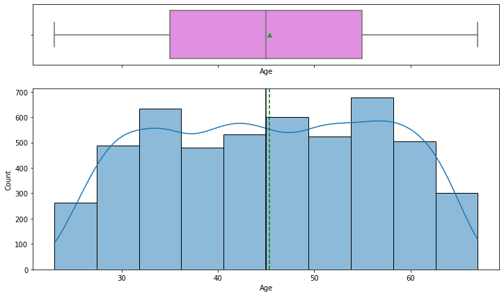

```python
#Age
box_hist_plot(data, 'Age')
```

> Age is normally distributed and no outliers

### Observations on Experience

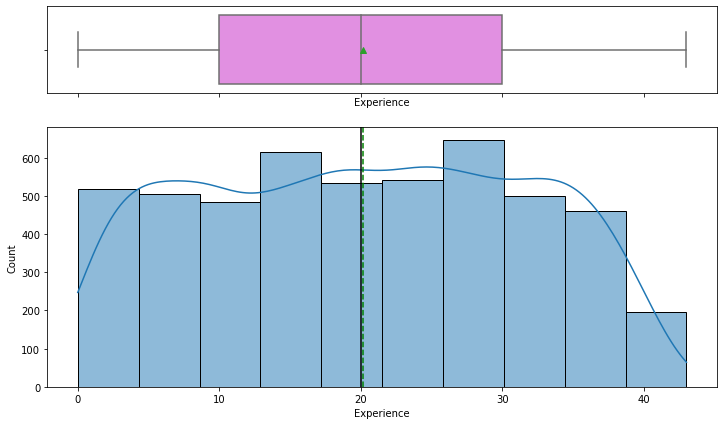

```python
#Experience
box_hist_plot(data, 'Experience')
```

> Professional experience of customers are normally distributed and there are no outliers

### Observations on Income

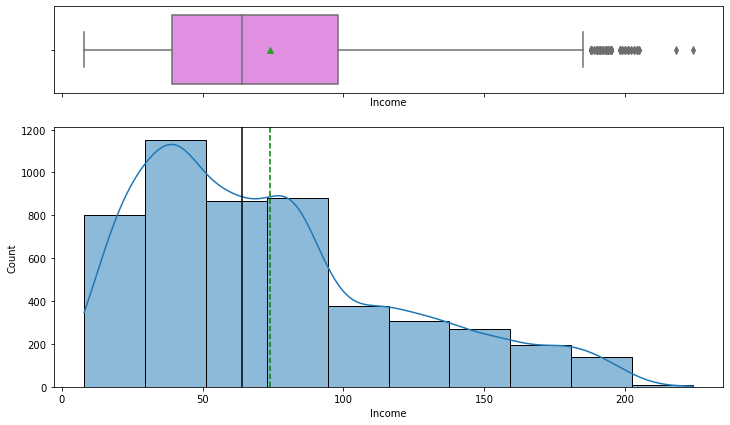

```python
#Income
box_hist_plot(data, 'Income')
```

> Income is right skewed with mean and median are separated by around 10K. Although this is not an issue for Logistic Regression or Decision Tree models. Below text is from the Logistic regression Literature

> "Logistic regression does not make many of the key assumptions of linear regression and general linear models that are based on ordinary least squares algorithms – particularly regarding linearity, normality, homoscedasticity, and measurement level."

> Hence we do not need to transform this column to Log normal or other similar transformations. We would follow the same approach for other columns as well.

### Observations on CCAvg

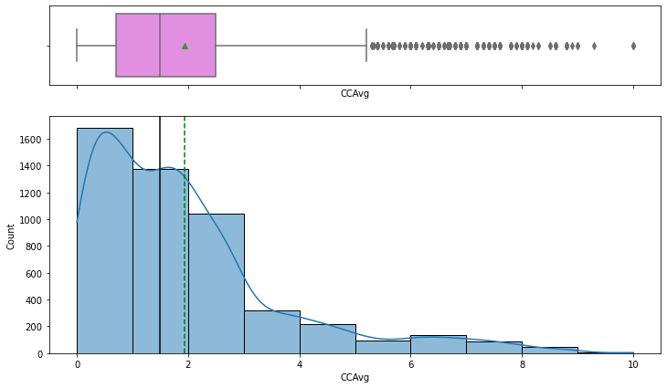

```python
#CCAvg
box_hist_plot(data, 'CCAvg')
```

> CCAvg has a right skew, and there are many outliers. But again outliers are not a big issue for Logistic Regression or Decision Tree models.

### Observations on Mortgage

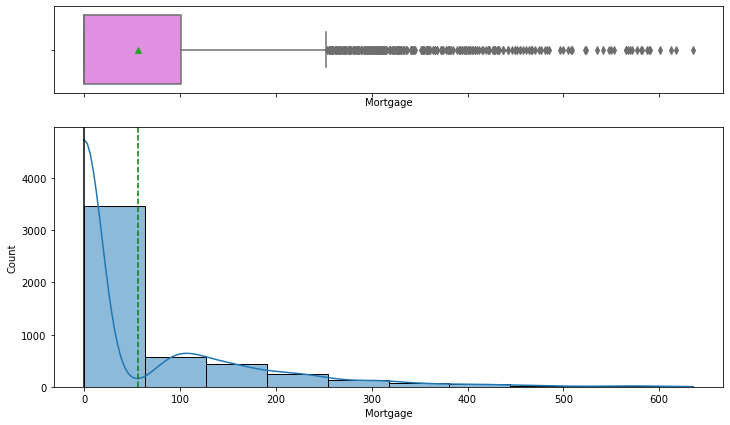

```python
#Mortgage
box_hist_plot(data, 'Mortgage')
```

```python
# Customers having higher mortgage have higher income and are older customers. This shows data is not misleading.
data[data.Mortgage > 500].sample(10)
```

|  | Age | Experience | Income | Family | CCAvg | Education | Mortgage | Personal_Loan | Securities_Account | CD_Account | Online | CreditCard | County_MI |
| --- | --- | --- | --- | --- | --- | --- | --- | --- | --- | --- | --- | --- | --- |
| 1789 | 44 | 20 | 171 | 4 | 0.7 | 1 | 567 | 1 | 0 | 1 | 1 | 1 | MI_<70 |
| 4859 | 34 | 8 | 165 | 1 | 7.0 | 3 | 541 | 1 | 0 | 0 | 0 | 0 | MI_<70 |
| 1937 | 51 | 25 | 181 | 1 | 3.3 | 3 | 589 | 1 | 1 | 1 | 1 | 0 | MI_<70 |
| 4655 | 33 | 7 | 188 | 2 | 7.0 | 2 | 581 | 1 | 0 | 0 | 0 | 0 | MI_<70 |
| 1783 | 53 | 27 | 192 | 1 | 1.7 | 1 | 601 | 0 | 0 | 0 | 1 | 0 | MI_<70 |
| 303 | 49 | 25 | 195 | 4 | 3.0 | 1 | 617 | 1 | 0 | 0 | 0 | 0 | MI_<60 |
| 1716 | 32 | 8 | 200 | 2 | 6.5 | 1 | 565 | 0 | 0 | 0 | 1 | 0 | MI_<70 |
| 4345 | 26 | 1 | 184 | 2 | 4.2 | 3 | 577 | 1 | 0 | 1 | 1 | 1 | MI_<70 |
| 2956 | 62 | 38 | 195 | 4 | 5.2 | 3 | 522 | 1 | 0 | 1 | 1 | 1 | MI_<70 |
| 4585 | 35 | 11 | 180 | 1 | 3.6 | 3 | 571 | 1 | 0 | 1 | 1 | 1 | MI_<60 |

### Observations on Family

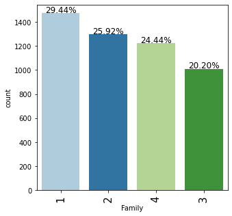

```python
bar_perc_plot(data, 'Family')
```

> Most of the families have single member follwed by 2, 4 and 3 members.

### Observations on Education

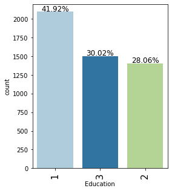

```python
bar_perc_plot(data, 'Education')
```

> Most of customers are Undergraduate followed by Advanced degree and Graduate

### Observations on Personal_Loan

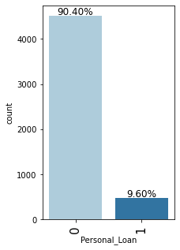

```python
bar_perc_plot(data, 'Personal_Loan')
```

> - 90.4% of customers have not responded or signed up for Personal Loan
> - Only 9.6% of customers have responded to the Personal Loan campaign.
> - Conversion rate of the campaign is below 10%.

### Observations on Securities_Account

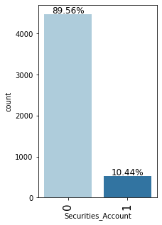

```python
bar_perc_plot(data, 'Securities_Account')
```

> A little over 10% customers have Securities account with the bank.

### Observations on CD_Account

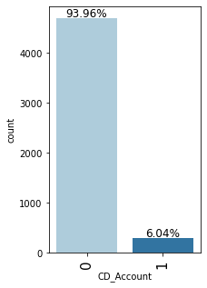

```python
bar_perc_plot(data, 'CD_Account')
```

> Only around 6% customers have CD account with the bank.

### Observations on Online

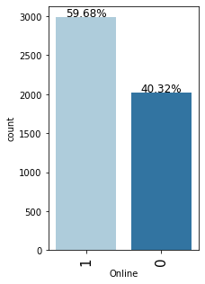

```python
bar_perc_plot(data, 'Online')
```

### Observations on CreditCard

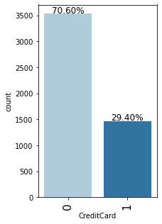

```python
bar_perc_plot(data, 'CreditCard')
```

> Around 29% customers use Credit cards from other banks which are not issued by AllLife Bank

### Observations on Customer Locations

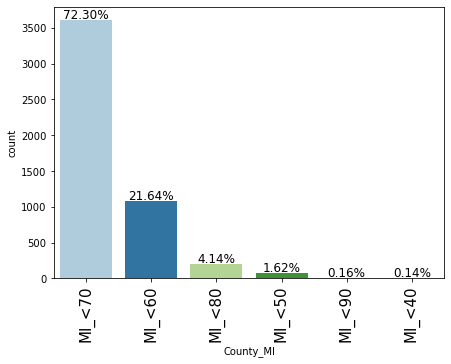

```python
bar_perc_plot(data, 'County_MI')
```

> - More than 70% customers are from Couties where median income is between 60K to 70K.
> - Only few customers less than 1% are from very high income counties or very low income counties.

## Multivariate Analysis

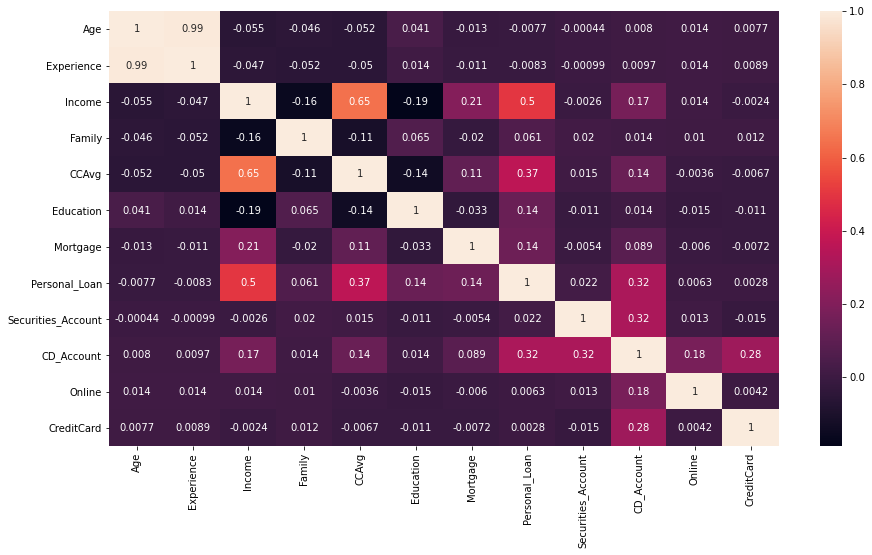

```python
# Check the correlation between features
plt.figure(figsize=(15,8))
sns.heatmap(data.corr(), annot=True);
```

> - Age and Experience are very strongly correlated. We will remove 'Experience' feature during our model building.
> - Income and monthly credit card average are correlated but it is not very high.
> - Also there is a little correlation between Income and Personal Loan
> - Otherwise most of the features are not very correlated to each other

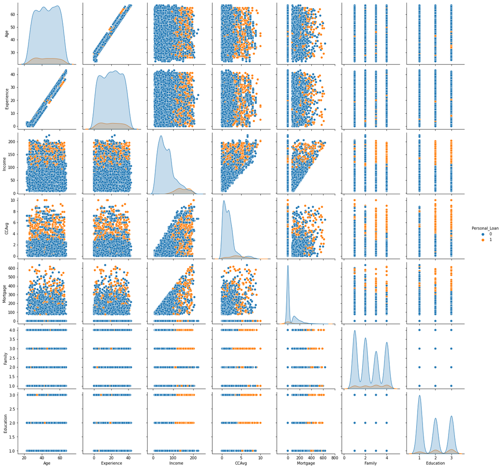

```python
# Draw Pair plot excluding the binary columns, we need to check the binary columns separately as they don't produce good result in pairplots
sns.pairplot(
    data[['Age', 'Experience', 'Income', 'CCAvg', 'Mortgage', 'Family', 'Education', 'Personal_Loan']],
    hue='Personal_Loan'
);
```

> **Observations**:
> - Here again we see Age and Experience are very strongly correlated.
> - Interesting to see that customers who have resonded to the Personal Loan campaign occupy different space in the pair plots.
> - Domain space of Personal Loan customers are towards higher Income, CCAvg, Mortgage, Family members and Education
> - Personal Loan customers belong to all Age and Experience in general.

### Distribution of Personal Loan with Non-Categorical features

Ignoring the outliers let's check the distribution of Personal Loan takers based on the non-categorical features

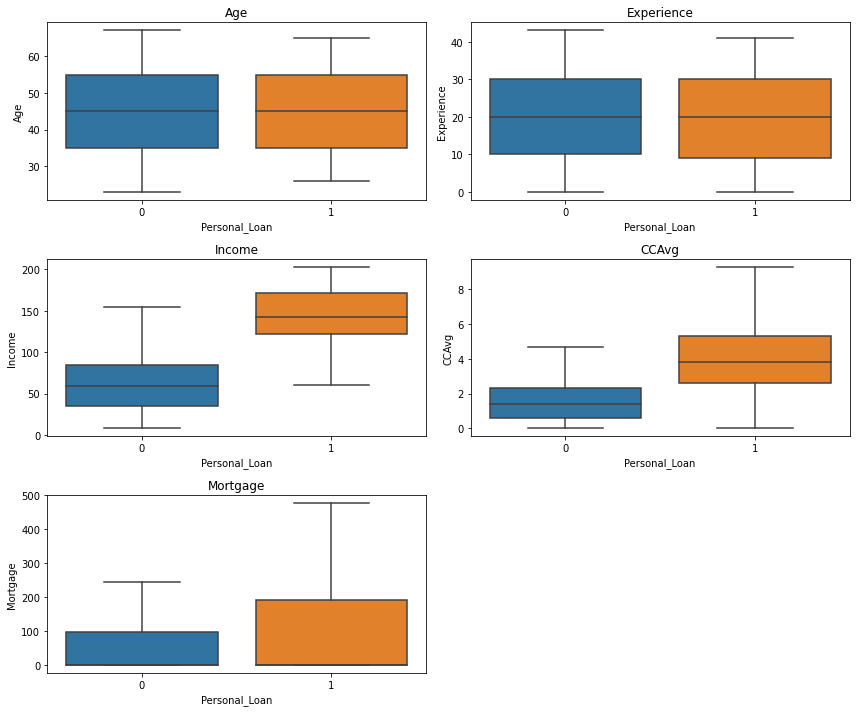

```python
cols = data[
    [
        "Age",
        "Experience",
        "Income",
        "CCAvg",
        "Mortgage"
    ]
].columns.tolist()
plt.figure(figsize=(12, 10))

for i, variable in enumerate(cols):
    plt.subplot(3, 2, i + 1)
    sns.boxplot(data = data, x="Personal_Loan", y=variable, showfliers=False)
    plt.tight_layout()
    plt.title(variable)
plt.show()
```

> **Observations**:
> - Distribution of Personal Loan customers have higher lower bound and lower upper bound when its comes to Age, compared to its other counterpart.
> - Not much difference with regards to Experience between customers with Personal Loan 1 and 0
> - Income and CCAge charts clearly tells Personal Loan customers have higher Income and CCAvge in general.
> - Although Personal Loan customers spreads across all Morgage ranges but higher mortgage customers are more Personal Loan takers in general.

### Distribution of Personal Loan with Categorical features

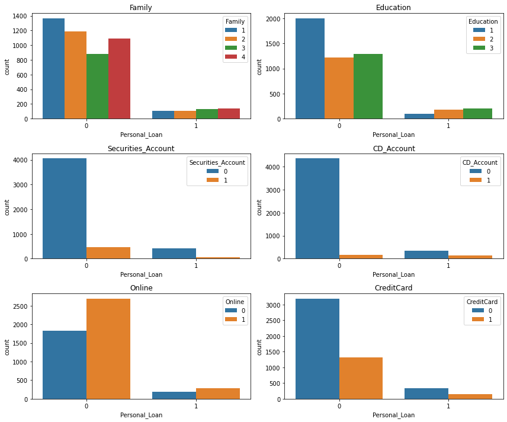

```python
cols = data[
    [
        "Family",
        "Education",
        "Securities_Account",
        "CD_Account",
        "Online",
        "CreditCard"
    ]
].columns.tolist()
plt.figure(figsize=(12, 10))

for i, variable in enumerate(cols):
    plt.subplot(3, 2, i + 1)
    sns.countplot(data = data, x='Personal_Loan', hue=variable)
    plt.tight_layout()
    plt.title(variable)
plt.show()
```

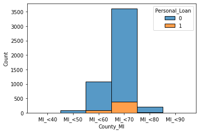

```python
# Finally check the Personal Loan customer distribution across counties
sns.histplot(data = data, x='County_MI', hue='Personal_Loan', multiple='stack');
```

> - Most of the Personal Loan customers are from couties where median income is between 60K to 70K. But this may be misleading as most customers are also from these counties.
> - There are no Personal Loan customers from very high income or very low income counties.

## Model Building for Cassification

We are going to now build two types of classification models, first with Logistic Regression followed by Decision Tree to address the key questions. But in both cases model evaluation criteria remains same. At the end we'll compare the performance of both types of models and and recommendations for AllLife Bank's marketing department Personal Loan campaign.

### Model evaluation criterion:

### Model can make wrong predictions as:

1. Predicting a person who has taken a personal loan but in reality he/she did not.
2. Predicting a person who did not take a personal loan but in reality he/she did.

### Which case is more important?

- Predicting a person who has taken a personal loan but in reality he/she did not then cost related to campaign on personal loan to the customer is wasted. Campaign cost per customer is generally not significant.
- If we predict a person who did not take a personal loan but in reality he/she did then it will be loss of oppertunity for the company and this is precisly we want to avoid since we want to increase the customer base of personal loan.

### How to reduce this loss i.e need to reduce False Negatives?

- `recall` should be maximized, the greater the `recall` higher the chances of identifying customers who would like to buy a personal loan product.

## Model Building with Logistic Regression

```python
# Lets take a backup of the prepared dataset
data_bkp = data.copy()

# Drop the Experience column as it is very strongly correlated with Age
data.drop(['Experience'], axis=1, inplace=True)
```

```python
# Take a look at first few rows
data.head()
```

|  | Age | Income | Family | CCAvg | Education | Mortgage | Personal_Loan | Securities_Account | CD_Account | Online | CreditCard | County_MI |
| --- | --- | --- | --- | --- | --- | --- | --- | --- | --- | --- | --- | --- |
| 0 | 25 | 49 | 4 | 1.6 | 1 | 0 | 0 | 1 | 0 | 0 | 0 | MI_<70 |
| 1 | 45 | 34 | 3 | 1.5 | 1 | 0 | 0 | 1 | 0 | 0 | 0 | MI_<70 |
| 2 | 39 | 11 | 1 | 1.0 | 1 | 0 | 0 | 0 | 0 | 0 | 0 | MI_<70 |
| 3 | 35 | 100 | 1 | 2.7 | 2 | 0 | 0 | 0 | 0 | 0 | 0 | MI_<60 |
| 4 | 35 | 45 | 4 | 1.0 | 2 | 0 | 0 | 0 | 0 | 0 | 1 | MI_<70 |

```python
# To build model for prediction
from sklearn.linear_model import LogisticRegression

# Library to split data
from sklearn.model_selection import train_test_split

# To get diferent metric scores
from sklearn.metrics import (
    f1_score,
    accuracy_score,
    recall_score,
    precision_score,
    confusion_matrix,
    roc_auc_score,
    plot_confusion_matrix,
    precision_recall_curve,
    roc_curve,
)
```

#### Create Traing and Test sets

We'll be using the same traing and test sets for both classification algorithms.

```python
X = data.drop(['Personal_Loan'], axis=1)
y = data['Personal_Loan']

X = pd.get_dummies(X, drop_first=True)

# Splitting data in train and test sets, with stratify so that data is split in a stratified fashion
X_train, X_test, y_train, y_test = train_test_split(X, y, test_size=0.30, random_state=1, stratify=y)
```

```python
print("Shape of Training set : ", X_train.shape)
print("Shape of test set : ", X_test.shape)
print("Percentage of classes in training set:")
print(y_train.value_counts(normalize=True))
print("Percentage of classes in test set:")
print(y_test.value_counts(normalize=True))
```

```
Shape of Training set :  (3500, 15)
Shape of test set :  (1500, 15)
Percentage of classes in training set:
0    0.904
1    0.096
Name: Personal_Loan, dtype: float64
Percentage of classes in test set:
0    0.904
1    0.096
Name: Personal_Loan, dtype: float64
```

In order to calculate different metrics and confusion matrix and promote code reuse we are going to write two utility functions as below.

- The show_model_perf_with_threshold function will be used to check the model performance of models.
- The show_confusion_matrix_with_threshold function will be used to plot confusion matrix.

```python
# defining a function to compute different metrics to check performance of a classification model built using sklearn

def show_model_perf_with_threshold(model, predictors, target, threshold=0.5):
    """
    Function to compute different metrics such as Accuracy, Recall, Precision and F1, based on the threshold specified

    model: classifier
    predictors: independent variables
    target: dependent variable
    threshold: threshold for classifying the observation as class 1
    """

    # predicting using the independent variables
    pred_prob = model.predict_proba(predictors)[:, 1]
    pred_thres = pred_prob > threshold
    pred = np.round(pred_thres)

    acc = accuracy_score(target, pred)  # to compute Accuracy
    recall = recall_score(target, pred)  # to compute Recall
    precision = precision_score(target, pred)  # to compute Precision
    f1 = f1_score(target, pred)  # to compute F1-score

    # creating a dataframe of metrics
    df_perf = pd.DataFrame(
        {
            "Accuracy": acc,
            "Recall": recall,
            "Precision": precision,
            "F1": f1,
        },
        index=[0],
    )

    return df_perf
```

```python
# defining a function to plot the confusion_matrix of a classification model built using sklearn
def show_confusion_matrix_with_threshold(model, predictors, target, threshold=0.5):
    """
    To plot the confusion_matrix, based on the threshold specified, with percentages

    model: classifier
    predictors: independent variables
    target: dependent variable
    threshold: threshold for classifying the observation as class 1
    """
    pred_prob = model.predict_proba(predictors)[:, 1]
    pred_thres = pred_prob > threshold
    y_pred = np.round(pred_thres)

    cm = confusion_matrix(target, y_pred)
    labels = np.asarray(
        [
            ["{0:0.0f}".format(item) + "\n{0:.2%}".format(item / cm.flatten().sum())]
            for item in cm.flatten()
        ]
    ).reshape(2, 2)

    plt.figure(figsize=(6, 4))
    sns.heatmap(cm, annot=labels, fmt="")
    plt.ylabel("True label")
    plt.xlabel("Predicted label")
```

### Logistic Regression

```python
# There are different solvers available in Sklearn logistic regression
# The newton-cg solver is faster for high-dimensional data

# Since the Personal Loan values are unbalanced and only 9.6 percent are 1s
# we are going to give more weight to value 1 as this is our target
lg = LogisticRegression(solver="newton-cg", random_state=1, class_weight={0: 0.1, 1: 0.9})
model = lg.fit(X_train, y_train)
```

```python
# let us check the coefficients and intercept of the model
coef_df = pd.DataFrame(
    np.append(lg.coef_, lg.intercept_),
    index=X_train.columns.tolist() + ["Intercept"],
    columns=["Coefficients"],
)
coef_df.sort_values(by='Coefficients', ascending=False)
```

|  | Coefficients |
| --- | --- |
| CD_Account | 2.507626 |
| Education | 1.355768 |
| Family | 0.550467 |
| County_MI_MI_<80 | 0.249739 |
| County_MI_MI_<70 | 0.192916 |
| CCAvg | 0.165054 |
| Income | 0.055098 |
| Age | 0.009471 |
| Mortgage | 0.000642 |
| County_MI_MI_<90 | -0.079239 |
| County_MI_MI_<50 | -0.112133 |
| County_MI_MI_<60 | -0.198342 |
| Securities_Account | -0.470967 |
| Online | -0.592422 |
| CreditCard | -0.810877 |
| Intercept | -10.859126 |

### Coefficient interpretations

Logistic regression model equation is not a liner one, hence coefficients will not have direct liner/proportional contributions. But a positive coefficient will have some degree of positive influence and vice versa.

- Coefficient of Age, Income, Family, CCAvg, Education, Mortgage, CD_Account are positive, increase in these will lead to increase in chances of a person taking Personal Loan it seems.
- Coefficient of Securities_Account, Online and CreditCard are negative hence increase in these will lead to decrease in chances of a person taking Personal Loan.
- People from Counties having median income between 60K to 70K and 70K to 80K have higher chances of taking Personal Loan than other couties based on the coefficient signs.

### Converting coefficients to odds

```python
# converting coefficients to odds
odds = np.exp(lg.coef_[0])

# finding the percentage change
perc_change_odds = (np.exp(lg.coef_[0]) - 1) * 100

# adding the odds to a dataframe
odd_df = pd.DataFrame({"Odds": odds, "Change_odd%": perc_change_odds}, index=X_train.columns)
odd_df.sort_values(by='Change_odd%', ascending=False)
```

|  | Odds | Change_odd% |
| --- | --- | --- |
| CD_Account | 12.275749 | 1127.574888 |
| Education | 3.879740 | 287.973957 |
| Family | 1.734063 | 73.406342 |
| County_MI_MI_<80 | 1.283690 | 28.369010 |
| County_MI_MI_<70 | 1.212781 | 21.278072 |
| CCAvg | 1.179456 | 17.945646 |
| Income | 1.056644 | 5.664371 |
| Age | 1.009516 | 0.951577 |
| Mortgage | 1.000642 | 0.064184 |
| County_MI_MI_<90 | 0.923820 | -7.618047 |
| County_MI_MI_<50 | 0.893925 | -10.607475 |
| County_MI_MI_<60 | 0.820089 | -17.991098 |
| Securities_Account | 0.624398 | -37.560208 |
| Online | 0.552986 | -44.701352 |
| CreditCard | 0.444468 | -55.553196 |

### Coefficient interpretations

- `CD_Account`: Holding all other features constant a 1 unit change in CD_Account will increase the odds of a person taking Personal Loan by 12.27 times or more than 1000% increase in odds for the same.
- `Income`: Holding all other features constant a 1 unit change in Income will increase the odds of a person taking Personal Loan by 1.057 times or a 5.67% increase in odds for the same.
- `Family`: Holding all other features constant a 1 unit change in Family will increase the odds of a person taking Personal Loan by 1.73 times or a 73.40% increase in odds for the same.
- `CreditCard`: Holding all other features constant a 1 unit change in the CreditCard will decrease the odds of a person taking Personal Loan by 0.44 times or a 55.55% decrease in odds for the same.

`Interpretation for other attributes can be done similarly.`

#### Checking model performance on Training set

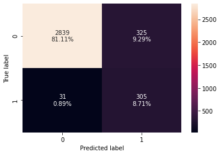

```python
# creating confusion matrix
show_confusion_matrix_with_threshold(lg, X_train, y_train)
```

```python
log_reg_model_train_perf = show_model_perf_with_threshold(lg, X_train, y_train)
print("Training performance:")
log_reg_model_train_perf
```

```
Training performance:
```

|  | Accuracy | Recall | Precision | F1 |
| --- | --- | --- | --- | --- |
| 0 | 0.898286 | 0.907738 | 0.484127 | 0.63147 |

#### Checking model performance on Test set

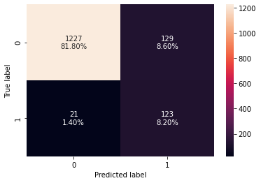

```python
# creating confusion matrix
show_confusion_matrix_with_threshold(lg, X_test, y_test)
```

```python
log_reg_model_test_perf = show_model_perf_with_threshold(lg, X_test, y_test)
print("Test set performance:")
log_reg_model_test_perf
```

```
Test set performance:
```

|  | Accuracy | Recall | Precision | F1 |
| --- | --- | --- | --- | --- |
| 0 | 0.9 | 0.854167 | 0.488095 | 0.621212 |

> **Observations**:
> - Both Training and Test sets have very high accuracy which is natural as Target variable is very unbalanced.
> - Training set **Recall** is 0.9 and test set recall is 0.85, this shows the model is not overfitted, but there may be room for improvements.
> - Precision is about 0.5 for both sets. This should be fine as we are looking for a higher recall score.

Let's compute Area Under the Receiver Operating Characteristic Curve (ROC AUC) from prediction scores.

#### ROC-AUC on Traing set

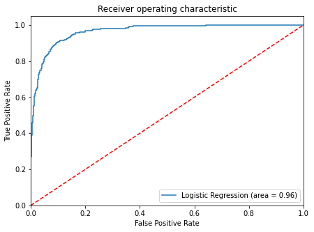

```python
## ROC-AUC on the Training Set
logit_roc_auc_train = roc_auc_score(y_train, lg.predict_proba(X_train)[:, 1])
fpr, tpr, thresholds = roc_curve(y_train, lg.predict_proba(X_train)[:, 1])
plt.figure(figsize=(7, 5))
plt.plot(fpr, tpr, label="Logistic Regression (area = %0.2f)" % logit_roc_auc_train)
plt.plot([0, 1], [0, 1], "r--")
plt.xlim([0.0, 1.0])
plt.ylim([0.0, 1.05])
plt.xlabel("False Positive Rate")
plt.ylabel("True Positive Rate")
plt.title("Receiver operating characteristic")
plt.legend(loc="lower right")
plt.show()
```

#### ROC-AUC on Test set

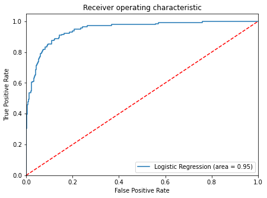

```python
# ROC-AUC on the test set
logit_roc_auc_test = roc_auc_score(y_test, lg.predict_proba(X_test)[:, 1])
fpr, tpr, thresholds = roc_curve(y_test, lg.predict_proba(X_test)[:, 1])
plt.figure(figsize=(7, 5))
plt.plot(fpr, tpr, label="Logistic Regression (area = %0.2f)" % logit_roc_auc_test)
plt.plot([0, 1], [0, 1], "r--")
plt.xlim([0.0, 1.0])
plt.ylim([0.0, 1.05])
plt.xlabel("False Positive Rate")
plt.ylabel("True Positive Rate")
plt.title("Receiver operating characteristic")
plt.legend(loc="lower right")
plt.show()
```

### Model Performance Improvement

Let's see if the recall score can be improved further, by changing the model threshold using AUC-ROC Curve.

```python
# Optimal threshold as per AUC-ROC curve
# The optimal cut off would be where tpr is high and fpr is low
fpr, tpr, thresholds = roc_curve(y_train, lg.predict_proba(X_train)[:, 1])

optimal_idx = np.argmax(tpr - fpr)
optimal_threshold_auc_roc = thresholds[optimal_idx]
print(optimal_threshold_auc_roc)
```

```
0.5097682293311234
```

### Optimal threshold using AUC-ROC curve

#### Model Performance on Training set with Optimal Threshold

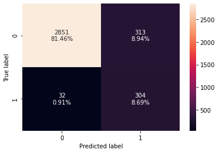

```python
# creating confusion matrix
show_confusion_matrix_with_threshold(
    lg, X_train, y_train, threshold=optimal_threshold_auc_roc
)
```

```python
# checking model performance for this model
log_reg_model_train_perf_threshold_auc_roc = show_model_perf_with_threshold(
    lg, X_train, y_train, threshold=optimal_threshold_auc_roc
)
print("Training performance:")
log_reg_model_train_perf_threshold_auc_roc
```

```
Training performance:
```

|  | Accuracy | Recall | Precision | F1 |
| --- | --- | --- | --- | --- |
| 0 | 0.901429 | 0.904762 | 0.492707 | 0.637985 |

#### Model Performance on Test set with Optimal Threshold

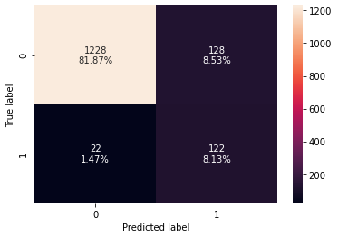

```python
# Test set
# creating confusion matrix
show_confusion_matrix_with_threshold(lg, X_test, y_test, threshold=optimal_threshold_auc_roc)
```

```python
# checking model performance for this model
log_reg_model_test_perf_threshold_auc_roc = show_model_perf_with_threshold(
    lg, X_test, y_test, threshold=optimal_threshold_auc_roc
)
print("Test set performance:")
log_reg_model_test_perf_threshold_auc_roc
```

```
Test set performance:
```

|  | Accuracy | Recall | Precision | F1 |
| --- | --- | --- | --- | --- |
| 0 | 0.9 | 0.847222 | 0.488 | 0.619289 |

> **Observations**:
> - Since the optimal threshold ~ 0.51 is close to default threshold 0.5 the scores did not change much.
> - Training set **Recall** is 0.9 and test set recall is around 0.85 - not much improvement is shown.
> - Precision and F1 scores are also similar with default threshold.

### Let's use Precision-Recall curve and see if we can find a better threshold

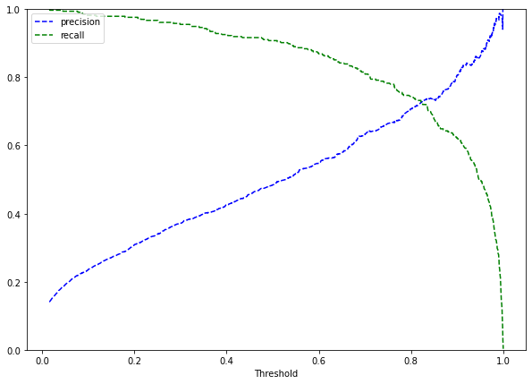

```python
y_scores = lg.predict_proba(X_train)[:, 1]
prec, rec, tre = precision_recall_curve(y_train, y_scores,)


def plot_prec_recall_vs_tresh(precisions, recalls, thresholds):
    plt.plot(thresholds, precisions[:-1], "b--", label="precision")
    plt.plot(thresholds, recalls[:-1], "g--", label="recall")
    plt.xlabel("Threshold")
    plt.legend(loc="upper left")
    plt.ylim([0, 1])


plt.figure(figsize=(10, 7))
plot_prec_recall_vs_tresh(prec, rec, tre)
plt.show()
```

> At threshold around 0.81 we will get equal precision and recall but taking a step back and selecting value around 0.40 will provide a higher recall and a acceptable precision.

```python
# setting the threshold
optimal_threshold_curve = 0.40
```

#### Model Performance on Training set

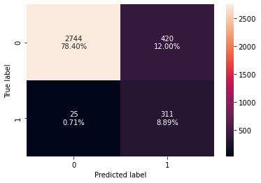

```python
# Training
# creating confusion matrix
show_confusion_matrix_with_threshold(lg, X_train, y_train, threshold=optimal_threshold_curve)
```

```python
log_reg_model_train_perf_threshold_curve = show_model_perf_with_threshold(
    lg, X_train, y_train, threshold=optimal_threshold_curve
)
print("Training performance:")
log_reg_model_train_perf_threshold_curve
```

```
Training performance:
```

|  | Accuracy | Recall | Precision | F1 |
| --- | --- | --- | --- | --- |
| 0 | 0.872857 | 0.925595 | 0.425445 | 0.582943 |

#### Model Performance on Test set

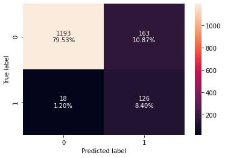

```python
# creating confusion matrix
show_confusion_matrix_with_threshold(lg, X_test, y_test, threshold=optimal_threshold_curve)
```

```python
log_reg_model_test_perf_threshold_curve = show_model_perf_with_threshold(
    lg, X_test, y_test, threshold=optimal_threshold_curve
)
print("Test set performance:")
log_reg_model_test_perf_threshold_curve
```

```
Test set performance:
```

|  | Accuracy | Recall | Precision | F1 |
| --- | --- | --- | --- | --- |
| 0 | 0.879333 | 0.875 | 0.435986 | 0.581986 |

> **Observations**:
> - With threshold 0.40 we are getting a little higher score for Recall but we have to sacrifice Precision.
> - Training set **Recall** is 0.92 and test set recall is around 0.875 - a little bit of improvement.
> - Precision and F1 scores have gone down with this new threshold.

### Model Performance Summary

```python
# training performance comparison

models_train_comp_df = pd.concat(
    [
        log_reg_model_train_perf.T,
        log_reg_model_train_perf_threshold_auc_roc.T,
        log_reg_model_train_perf_threshold_curve.T
    ],
    axis=1,
)
models_train_comp_df.columns = [
    "Logistic Regression sklearn",
    "Logistic Regression-0.51 Threshold",
    "Logistic Regression-0.40 Threshold"
]
print("Training performance comparison:")
models_train_comp_df.T.sort_values(by='Recall', ascending=False)
```

```
Training performance comparison:
```

|  | Accuracy | Recall | Precision | F1 |
| --- | --- | --- | --- | --- |
| Logistic Regression-0.40 Threshold | 0.872857 | 0.925595 | 0.425445 | 0.582943 |
| Logistic Regression sklearn | 0.898286 | 0.907738 | 0.484127 | 0.631470 |
| Logistic Regression-0.51 Threshold | 0.901429 | 0.904762 | 0.492707 | 0.637985 |

```python
# testing performance comparison

models_test_comp_df = pd.concat(
    [
        log_reg_model_test_perf.T,
        log_reg_model_test_perf_threshold_auc_roc.T,
        log_reg_model_test_perf_threshold_curve.T
        ],
    axis=1,
)
models_test_comp_df.columns = [
    "Logistic Regression sklearn",
    "Logistic Regression-0.51 Threshold",
    "Logistic Regression-0.40 Threshold"
]
print("Test set performance comparison:")
models_test_comp_df.T.sort_values(by='Recall', ascending=False)
```

```
Test set performance comparison:
```

|  | Accuracy | Recall | Precision | F1 |
| --- | --- | --- | --- | --- |
| Logistic Regression-0.40 Threshold | 0.879333 | 0.875000 | 0.435986 | 0.581986 |
| Logistic Regression sklearn | 0.900000 | 0.854167 | 0.488095 | 0.621212 |
| Logistic Regression-0.51 Threshold | 0.900000 | 0.847222 | 0.488000 | 0.619289 |

### Logistic Regression with Sequential Feature Selector

- Reduces dimensionality.
- Discards deceptive features (Deceptive features appear to aid learning on the training set, but impair generalization).
- Speeds training/testing.

Let's see with SFS what are the most important features and if we can get a better recall score using SFS.

```python
# !pip install mlxtend
# Sequential feature selector is present in mlxtend library
# !pip install mlxtend to install mlxtent library

from mlxtend.feature_selection import SequentialFeatureSelector as SFS

# to plot the performance with addition of each feature
from mlxtend.plotting import plot_sequential_feature_selection as plot_sfs
```

```python
# from sklearn.linear_model import LogisticRegression

# Fit the model on train
model = LogisticRegression(solver="newton-cg", n_jobs=-1, random_state=1, max_iter=100)
```

```python
# we will first build model with all varaible
sfs = SFS(
    model,
    k_features=15, # it is same as X_train.shape
    forward=True,
    floating=False,
    scoring="recall",
    verbose=2,
    cv=3,
    n_jobs=-1,
)

sfs = sfs.fit(X_train, y_train)
```

[output not shown]

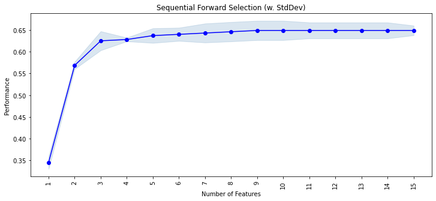

```python
fig1 = plot_sfs(sfs.get_metric_dict(), kind="std_dev", figsize=(12, 5))
#plt.ylim([0.8, 1])
plt.title("Sequential Forward Selection (w. StdDev)")
plt.xticks(rotation=90)
plt.show()
```

[output not shown]

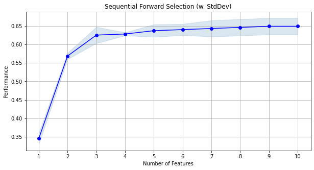

```python
sfs1 = SFS(
    model,
    k_features=10,
    forward=True,
    floating=False,
    scoring="recall",
    verbose=2,
    cv=3,
    n_jobs=-1,
)

sfs1 = sfs1.fit(X_train, y_train)

fig1 = plot_sfs(sfs1.get_metric_dict(), kind="std_dev", figsize=(10, 5))

#plt.ylim([0.8, 1])
plt.title("Sequential Forward Selection (w. StdDev)")
plt.grid()
plt.show()
```

**Finding which features are important?**

```python
feat_cols = list(sfs1.k_feature_idx_)
print(feat_cols)
```

```
[1, 2, 3, 4, 5, 6, 7, 8, 10, 12]
```

**Let's look at best 10 variables**

```python
X_train.columns[feat_cols]
```

```
Index(['Income', 'Family', 'CCAvg', 'Education', 'Mortgage',
       'Securities_Account', 'CD_Account', 'Online', 'County_MI_MI_<50',
       'County_MI_MI_<70'],
      dtype='object')
```

```python
X_train_final = X_train[X_train.columns[feat_cols]]

# Creating new x_test with the same variables that we selected for x_train
X_test_final = X_test[X_train_final.columns]
```

```python
lg_sfs = LogisticRegression(solver="newton-cg", random_state=1, class_weight={0: 0.1, 1: 0.9})
lg_sfs.fit(X_train_final, y_train)
```

```
LogisticRegression(class_weight={0: 0.1, 1: 0.9}, random_state=1,
                   solver='newton-cg')
```

### Let's Look at model performance with SFS

#### Training set performance

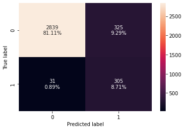

```python
show_confusion_matrix_with_threshold(lg_sfs, X_train_final, y_train)
```

```python
log_reg_model_train_perf_SFS = show_model_perf_with_threshold(lg_sfs, X_train_final, y_train)
print("Training performance:")
log_reg_model_train_perf_SFS
```

```
Training performance:
```

|  | Accuracy | Recall | Precision | F1 |
| --- | --- | --- | --- | --- |
| 0 | 0.898286 | 0.907738 | 0.484127 | 0.63147 |

#### Test set performance

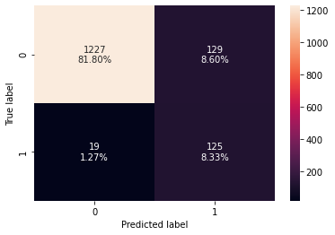

```python
show_confusion_matrix_with_threshold(lg_sfs, X_test_final, y_test)
```

```python
log_reg_model_test_perf_SFS = show_model_perf_with_threshold(lg_sfs, X_test_final, y_test)
print("Test set performance:")
log_reg_model_test_perf_SFS
```

```
Test set performance:
```

|  | Accuracy | Recall | Precision | F1 |
| --- | --- | --- | --- | --- |
| 0 | 0.901333 | 0.868056 | 0.492126 | 0.628141 |

> **Observations:**
> - Model is giving a generalized performance on training and test set.
> - With a fewer number of features, the model performance is comparable to the initial logistic regression model.

### Model Performance Summary with Logistic Regression

```python
# training performance comparison

models_train_comp_df = pd.concat(
    [
        log_reg_model_train_perf.T,
        log_reg_model_train_perf_threshold_auc_roc.T,
        log_reg_model_train_perf_threshold_curve.T,
        log_reg_model_train_perf_SFS.T,
    ],
    axis=1,
)
models_train_comp_df.columns = [
    "Logistic Regression sklearn",
    "Logistic Regression-0.51 Threshold",
    "Logistic Regression-0.40 Threshold",
    "Logistic Regression - SFS",
]
print("Training performance comparison:")
models_train_comp_df.T.sort_values(by='Recall', ascending=False)
```

```
Training performance comparison:
```

|  | Accuracy | Recall | Precision | F1 |
| --- | --- | --- | --- | --- |
| Logistic Regression-0.40 Threshold | 0.872857 | 0.925595 | 0.425445 | 0.582943 |
| Logistic Regression sklearn | 0.898286 | 0.907738 | 0.484127 | 0.631470 |
| Logistic Regression - SFS | 0.898286 | 0.907738 | 0.484127 | 0.631470 |
| Logistic Regression-0.51 Threshold | 0.901429 | 0.904762 | 0.492707 | 0.637985 |

```python
# testing performance comparison

models_test_comp_df = pd.concat(
    [
        log_reg_model_test_perf.T,
        log_reg_model_test_perf_threshold_auc_roc.T,
        log_reg_model_test_perf_threshold_curve.T,
        log_reg_model_test_perf_SFS.T,
    ],
    axis=1,
)
models_test_comp_df.columns = [
    "Logistic Regression sklearn",
    "Logistic Regression-0.51 Threshold",
    "Logistic Regression-0.40 Threshold",
    "Logistic Regression - SFS",
]
print("Test set performance comparison:")
models_test_comp_df.T.sort_values(by='Recall', ascending=False)
```

```
Test set performance comparison:
```

|  | Accuracy | Recall | Precision | F1 |
| --- | --- | --- | --- | --- |
| Logistic Regression-0.40 Threshold | 0.879333 | 0.875000 | 0.435986 | 0.581986 |
| Logistic Regression - SFS | 0.901333 | 0.868056 | 0.492126 | 0.628141 |
| Logistic Regression sklearn | 0.900000 | 0.854167 | 0.488095 | 0.621212 |
| Logistic Regression-0.51 Threshold | 0.900000 | 0.847222 | 0.488000 | 0.619289 |